# COVID eBirding: Preliminary analyses

Karthik Thrikkadeeri

2022/02/23

# Introduction

This study will focus on the impacts of the COVID-19 pandemic on both birds and the birding community in the Indian context. It will also try to understand the consequences of these changes on citizen science and the inferences that can be drawn from it. Lastly, it will propose guidelines for making the most of the available data while accounting for pandemic-driven biases and deviations from the pre-COVID normal.

To ensure a balanced time frame, this study will focus on the years from 2018 to 2021. The time period of 2018–19 will be considered as “pre-COVID” while 2020–21 will be considered “COVID.” In order to account for within-year variations in bird and birder behaviour, the comparisons will be made on the month level. For instance, various metrics of birding behaviour in the month of June will be compared between 2018–19 and 2020–21, and will not be confounded with patterns seen in other months.

## Questions

Are there any changes and gaps in the pandemic eBird data? These questions will be answered using numerous metrics calculated from the focal data point in eBird data, a checklist.

- What has happened to overall birding activity?
- What has happened to group birding? Has it decreased, as would be expected?
- Has birding effort changed with the pandemic?
- Are there biases in the pandemic birding activity in terms of spatial and temporal spread?

# Preliminary analyses

*This notebook is the preliminary analysis notebook for the study. Here, I explore, mainly via visualisations, the basic patterns in the data.*

Among other filters applied, the data being used is a random subset (100,000 unique lists) of the full data, in order to reduce storage and computational demands.

## COVID timeline at national and state levels

### National level

#### Waves:

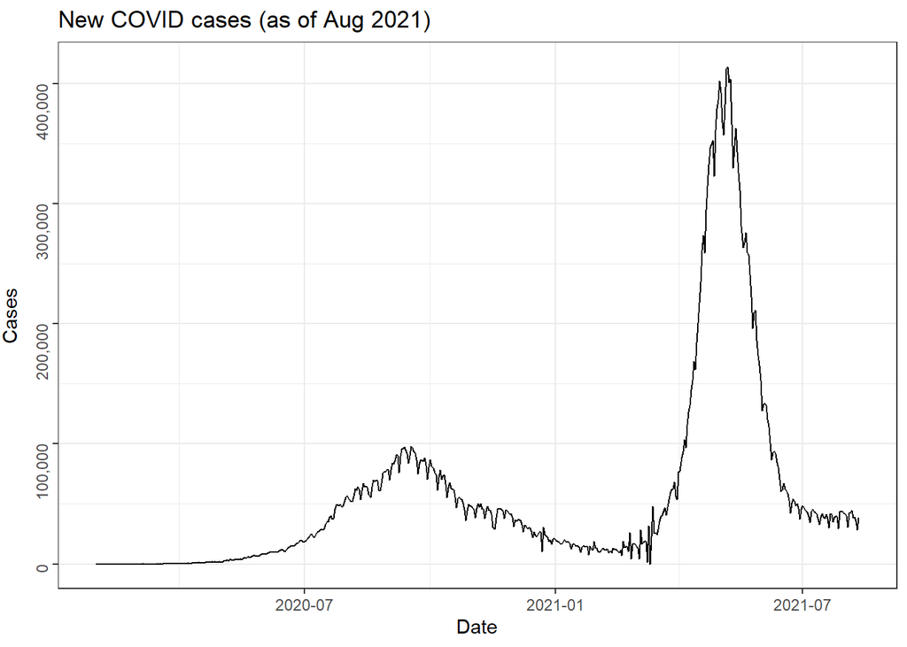

While there is no strict definition for a “wave” or “phase” of an epidemic (**wagnerWhatMakesWave?**), here we use the general connotation of a natural pattern of sharply defined peaks and valleys in the number of sick/infected individuals. As such, India has experienced two waves at the national level (see **worldhealthorganizationIndiaWHOCoronavirus?**).

#### Lockdowns:

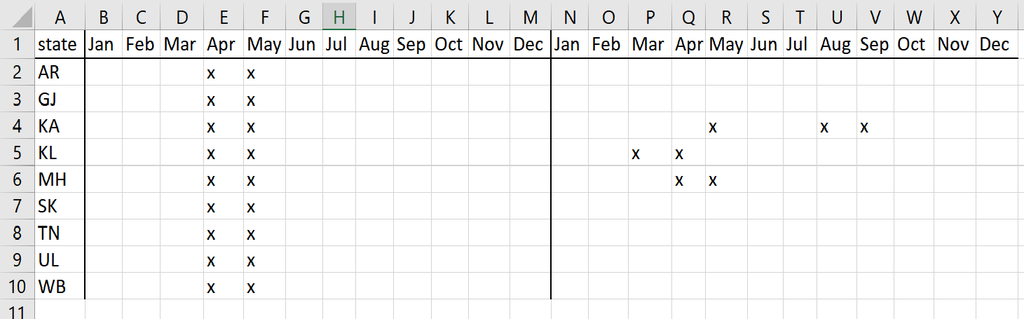

1. 24 March 2020–31 May 2020 (**CoronavirusIndiaEnters2020?**; **gettlemanModiOrders3Week2020?**; **banerjeaCoronavirusLockdownExtended2020?**; **LockdownGuidelinesNationwide2020?**)
2. Second phase: The second wave of the pandemic in India has seen no nationwide lockdown (**Covid19SecondWave2021?**; **sangalAnalysisAnotherNational2021?**).

#### Vaccination drives:

1. March 2021–June 2021
2. July 2021–mid-Aug 2021 (end of data)

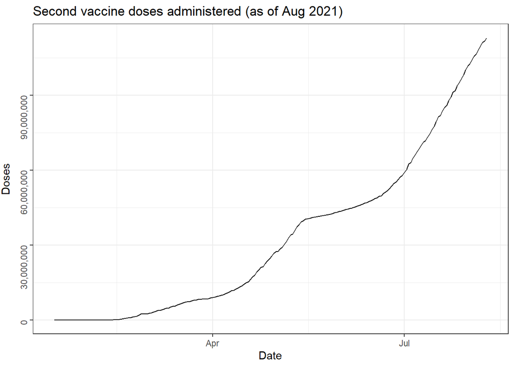

### State level

#### Kerala

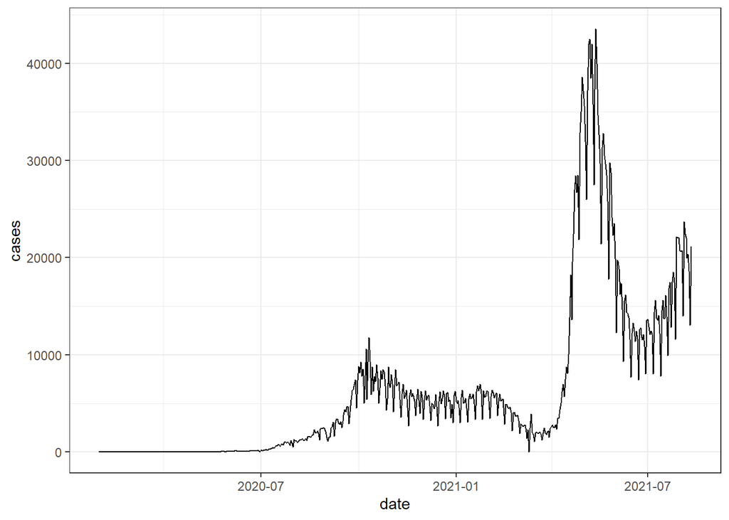

##### Waves:

1. September 2020–November 2020
2. January 2021–March 2021
3. April 2021–June 2021
4. August 2021–August 2021 (end of data)

##### Lockdowns:

1. 24 March 2020–31 May 2020
2. March 2021–April 2021  
   (**GoKDashboardOfficial?**)

#### Karnataka

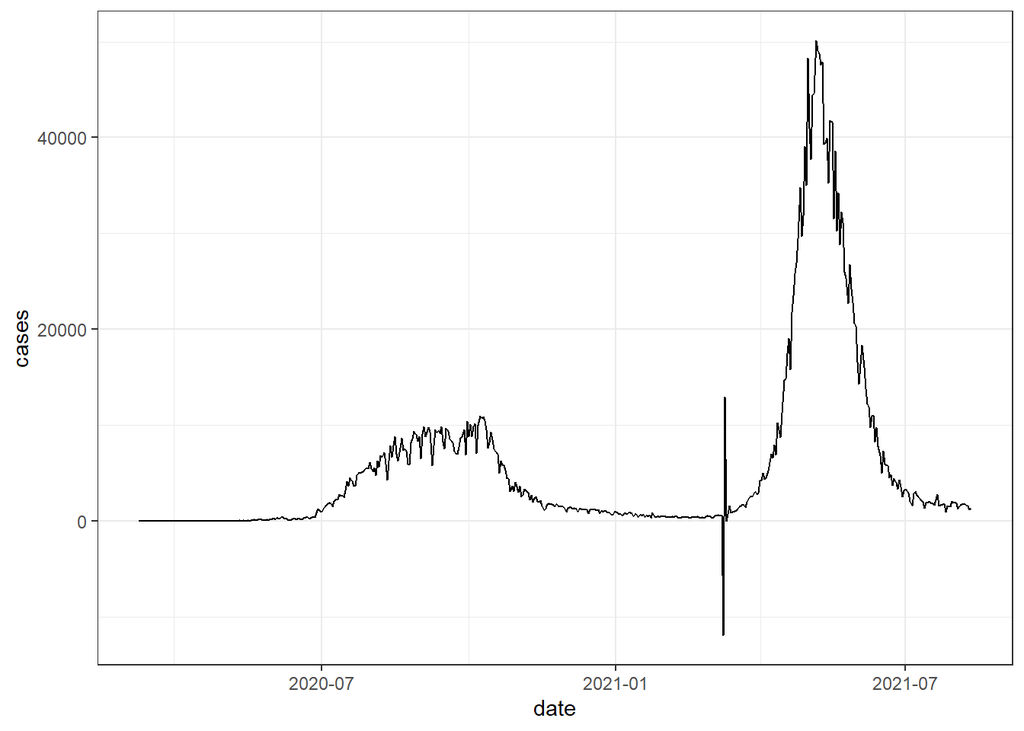

##### Waves:

1. July 2020–November 2020
2. April 2021–June 2021

##### Lockdowns:

1. 24 March 2020–31 May 2020
2. May 2021–May 2021 (**Covid19SecondWave2021?**)
3. August 2021–September 2021 (some districts) (**KarnatakaImposesWeekend2021?**)

#### Tamil Nadu

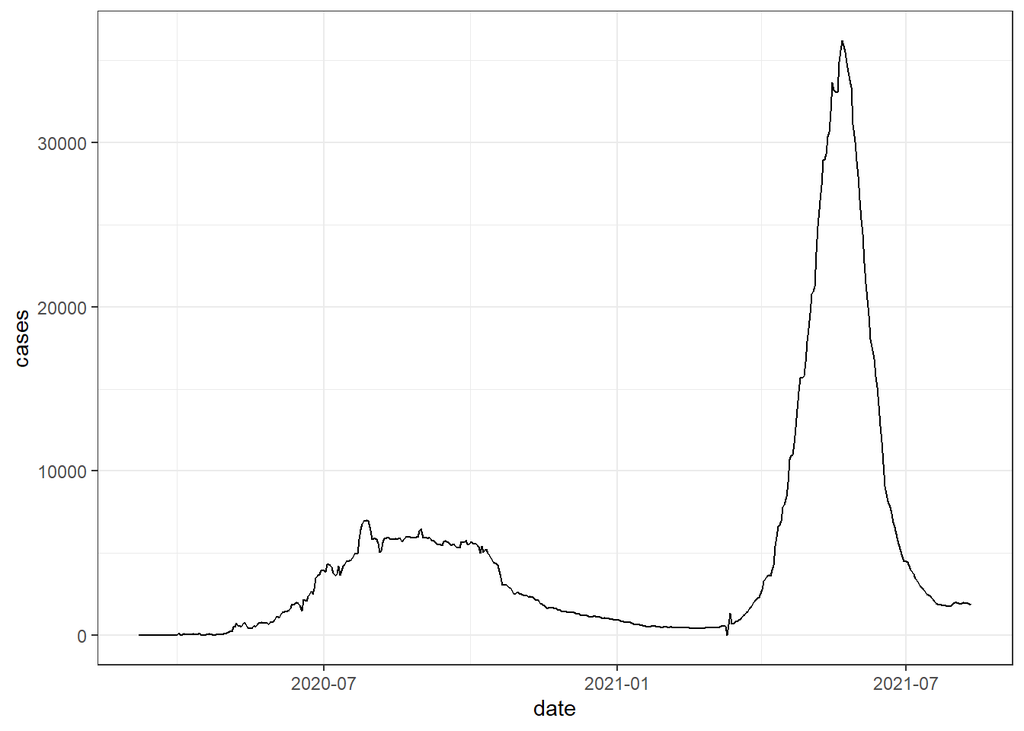

##### Waves:

1. June 2020–November 2020
2. April 2021–July 2021

##### Lockdowns:

1. 24 March 2020–31 May 2020

#### Maharashtra

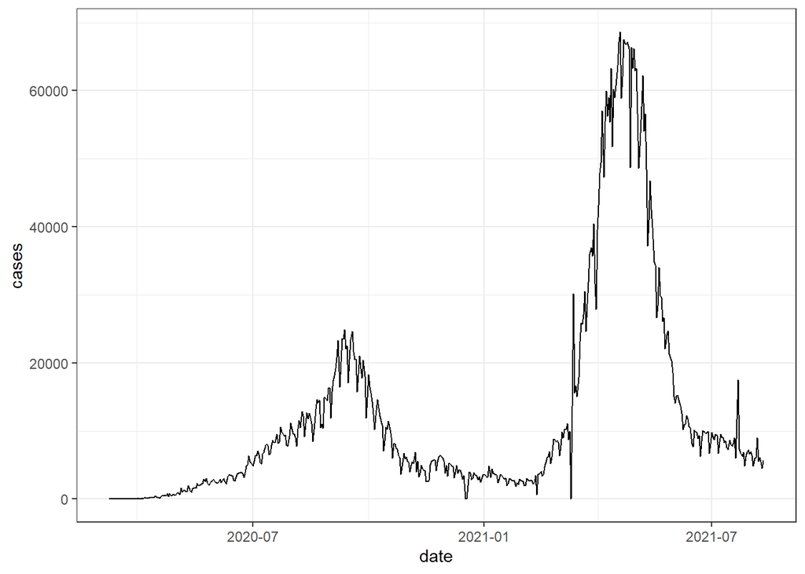

##### Waves:

1. July 2020–November 2020
2. March 2021–June 2021

##### Lockdowns:

1. 24 March 2020–31 May 2020
2. April 2021–May 2021 (**Covid19SecondWave2021?**)

#### Gujarat

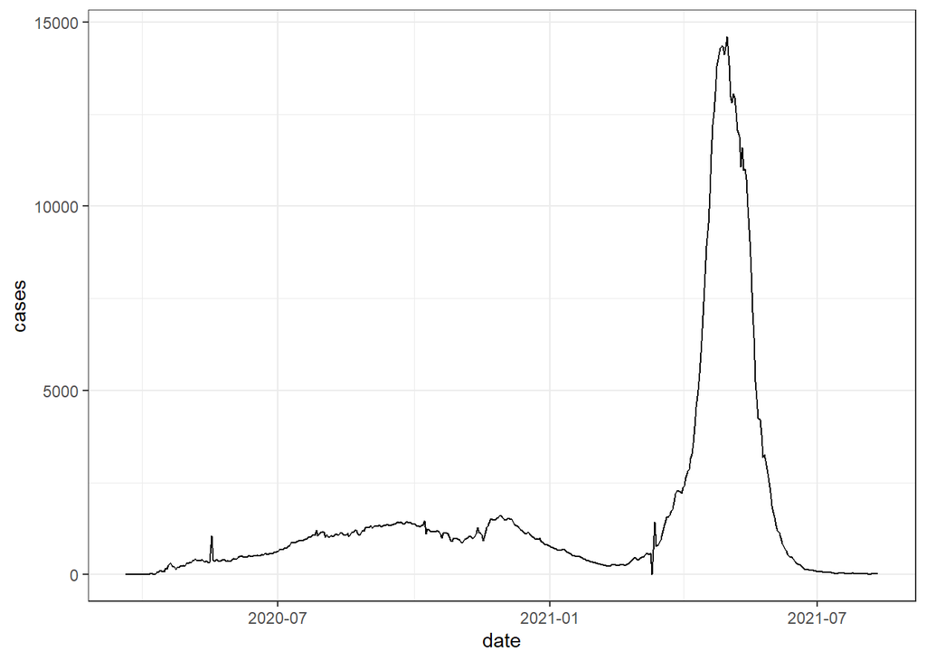

##### Waves:

1. April 2021–June 2021

##### Lockdowns:

1. 24 March 2020–31 May 2020
2. April 2021–June 2021 (only night curfew + other restrictions) (**LockdownGujaratNight2021?**; **GujaratCOVID19Restrictions2021?**) No state lockdowns. Only curfews and other restrictions. (**Covid19SecondWave2021?**)

[figure not shown]

##### Waves:

1. August 2020–December 2020
2. May 2021–August 2021 (end of data)

##### Lockdowns:

1. 24 March 2020–31 May 2020

#### West Bengal

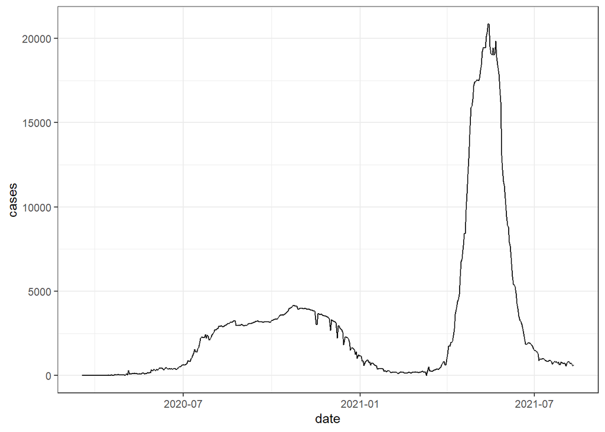

##### Waves:

1. July 2020–January 2021
2. April 2021–July 2021

##### Lockdowns:

1. 24 March 2020–31 May 2020

#### Sikkim

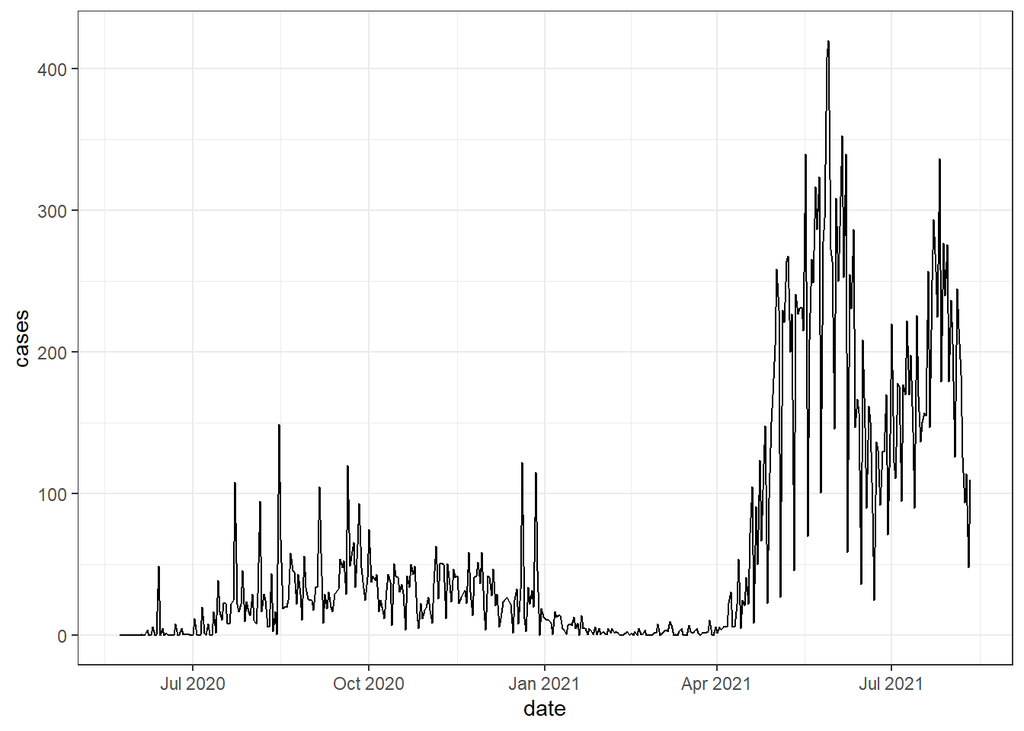

##### Waves:

1. April 2021–June 2021
2. July 2021–August 2021 (end of data)

##### Lockdowns:

1. 24 March 2020–31 May 2020

#### Uttarakhand

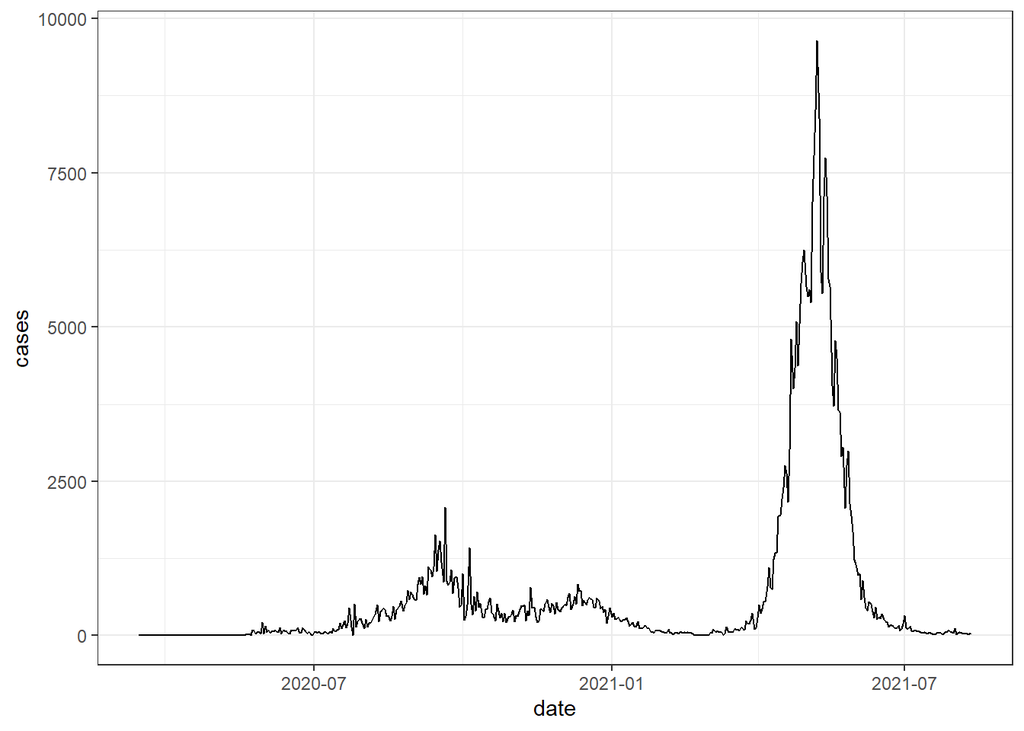

##### Waves:

1. August 2020–November 2020
2. December 2020–January 2021
3. April 2021–June 2021

##### Lockdowns:

1. 24 March 2020–31 May 2020

## Birder behaviour (focus level: checklists)

Changes in eBirder behaviour will be analysed using the focal data point, checklists. A number of metrics based on checklists will be calculated and analysed (**at the monthly scale**), such as:

1. Number of submitted checklists
   1. Total lists
   2. Shared lists (use no. of obs.)
2. Number of submitted checklists per observer
   1. Total lists
   2. Shared lists (use no. of obs.)
3. Hotspot birding
4. Birding protocol
5. Birding distance
6. Site fidelity per observer
7. Habitats surveyed
8. Spatial spread of birding activity. These spatial patterns will be explored at two scales too: nationwide and regional.
   1. Spatial spread by absences
   2. Spatial spread by densities
9. List duration
10. List length
11. Birding time per observer (monthly for prelim, later maybe daily)
12. Temporal spread of birding activity
    1. Temporal spread within day (time-of-day)
    2. Temporal spread within week (day-of-week)
13. Media
14. Number of new birders

When running the actual models, observer will be used as a random effect because all of these metrics would vary differently from observer to observer.

Aside from comparing trends before and during the pandemic, at a finer scale we will also try to find patterns matching the various waves of spread and complete lockdown, as well as the vaccination progress.

Post-presentation: regarding averaging national level patterns by state for some metrics, this means that means are manually calculated for states and the points plotted in the graph are only these single points per state (instead of all the raw data points).

### Group birding

Doesn’t include duplicate lists as we are interested in Boolean group/solo, and otherwise proportion will be inflated just by having more birders in the group birding session.

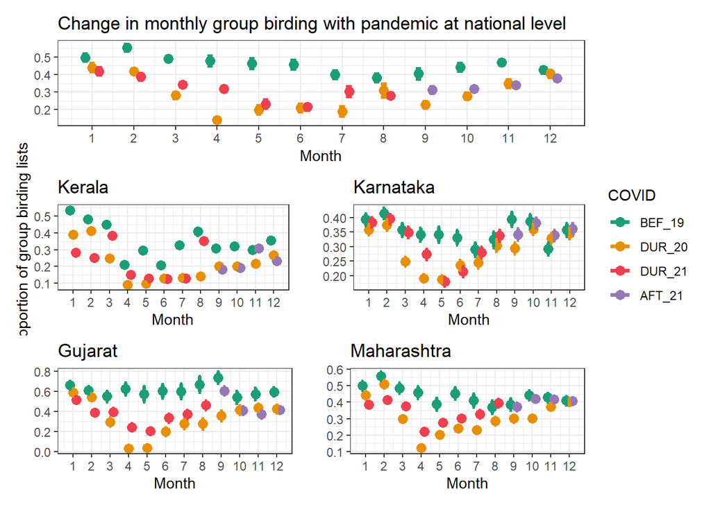

- At the national level, proportion of group birdin decreased drastically with pandemic, especially in the months of April, May and June. It also had a lasting effect in the months of Aug–Nov. In 2021 there is a very slight suggestion that group birding is rising back up.
- Kerala has also shown a decrease in group birding proportion, strongest during the national lockdown and the second wave, but month-to-month variation is very high.
- In Karnataka the pandemic affected mostly only the months of April, May and June. Proportions of group birding otherwise were similar to pre-COVID levels.
- Gujarat’s story was similar to Karnataka’s but slightly more exaggerated.
- Maharashtra shows very similar patterns to Karnataka’s.

### Group birding per observer

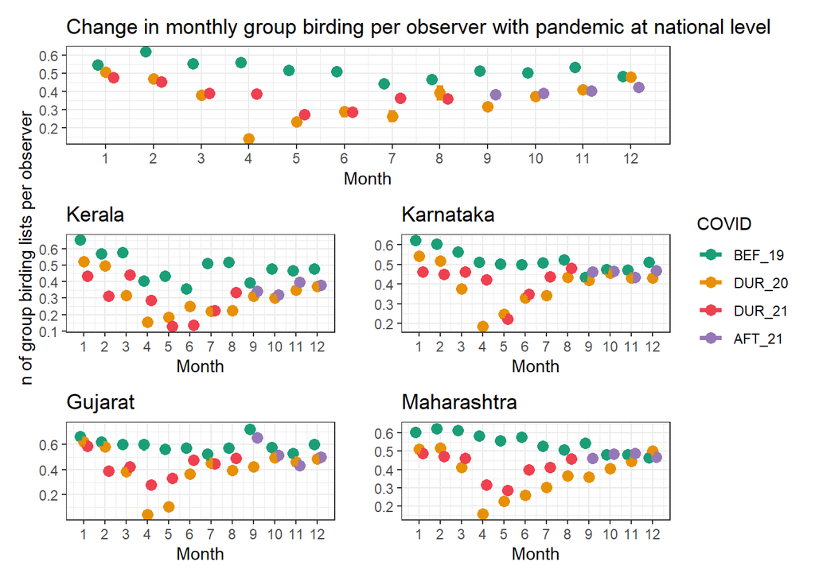

### Site fidelity per observer

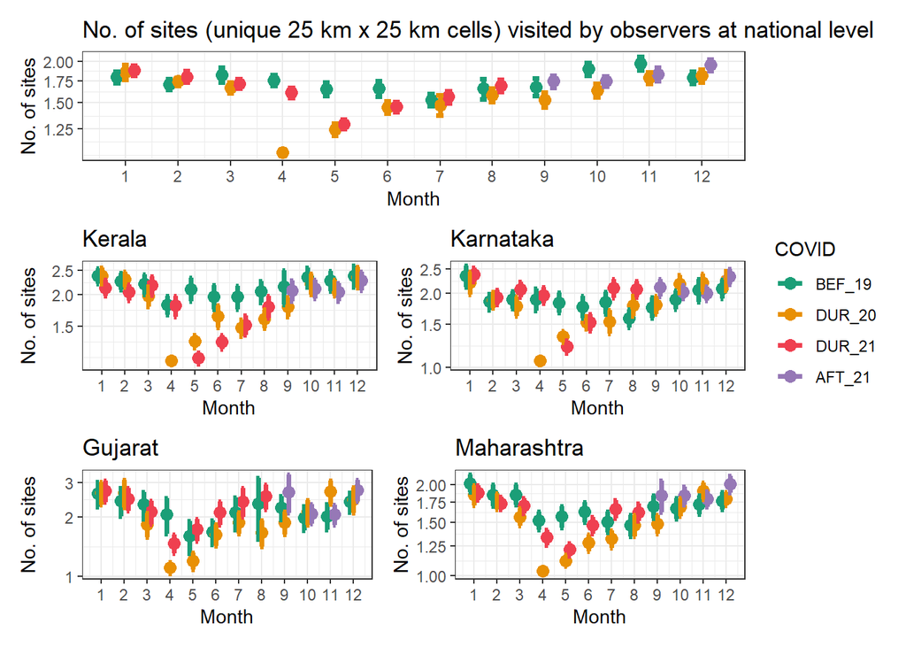

### Birding time per observer

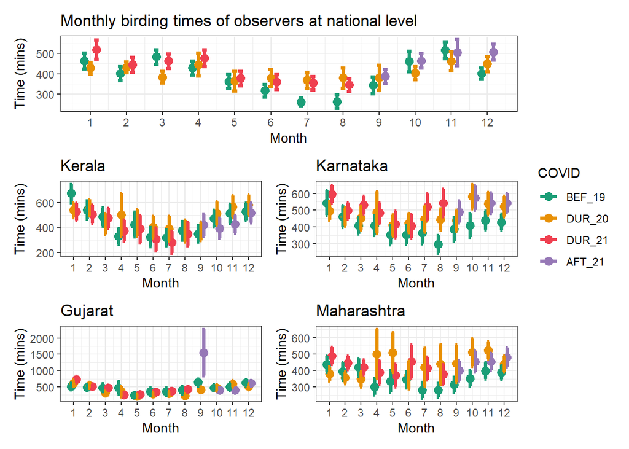

- At the national level, birding times were and are lowest during monsoon. There was no noticeable negative impact of the pandemic on monthly birding times, except in March 2020 when the pandemic was a novelty. In fact, in the monsoon months of July and August, birding times even increased slightly during the pandemic.
- The only other major pattern visible at the state level is in Karnataka, where birding times have increased in the months of August–October.

### Hotspot birding

Not “per observer,” as this metric from data POV. Includes duplicate lists, of course.

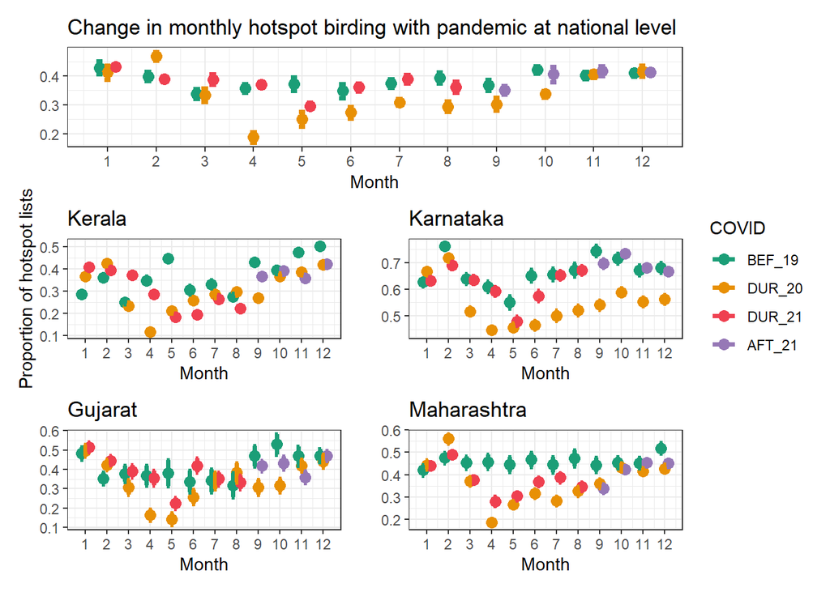

- The national level saw lower hotspot birding during the lockdown/second wave months, with some spillover into the months of June and July.
- Kerala mirrored the national level pattern with slightly higher month-to-month variability.
- In Karnataka, this impact surprisingly lasted through all of 2020 but returned almost exactly to pre-COVID levels in 2021.
- Gujarat and Maharashtra basically mirror the national pattern.

### Birding protocol

Not “per observer,” as this metric from data POV. Includes duplicate lists, of course.

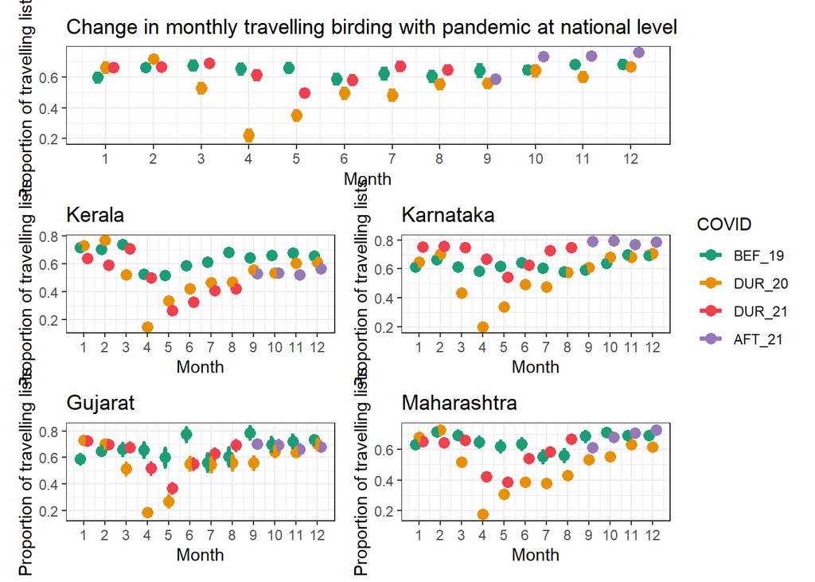

- At the national level, mobility of birders, in terms of proportion of travelling lists submitted, decreased sharply during April–May as expected, and had some spillover into June and July, but matched pre-COVID levels well in the other months of the year.
- In Kerala the pandemic has impacted all months of the year, except January and February which continue to have high proportions of travelling lists, possibly due mass birding events such as GBBC and AWC. Otherwise, even “after” the pandemic, mobility is much lower than before the pandemic.
- Karnataka was mostly only affected during the months of March–May, with spillover into June and July. Moreover, this impact was only in 2020 and not 2021.
- Gujarat and Maharashtra show high month-to-month variability but suggest somewhat similar patterns as at the national level.

### Birding distance

Not “per observer,” as this metric from data POV. Includes duplicate lists, of course. Only considers travelling lists.

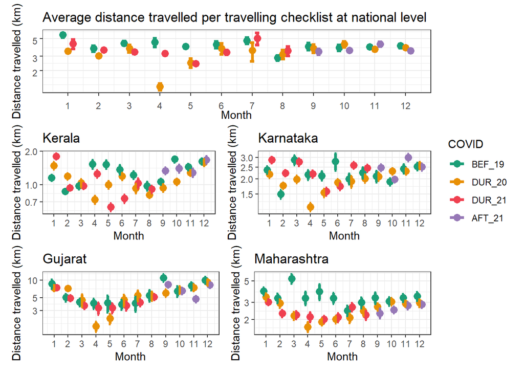

### List duration

Not “per observer,” as this metric from data POV. Includes duplicate lists, of course.

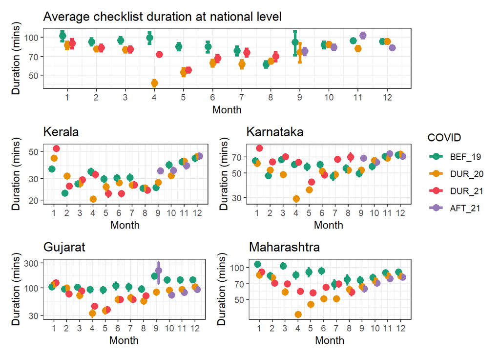

### List length

Not “per observer,” as this metric from data POV. Includes duplicate lists, of course.

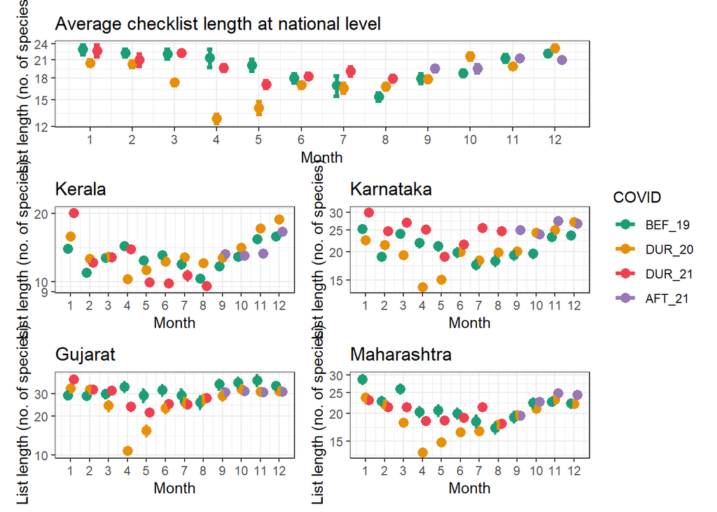

- At the national level, list length decreased only in April–May. Over all years, the average checklist becomes bigger in the winter (due to winter migrants adding to the local species pool).
- In Kerala, list length increased in the winter months of December–January during the pandemic, but otherwise mirrored national patterns.
- Other states mirrored national patterns with more or less degree of variablity.

### Spatial spread

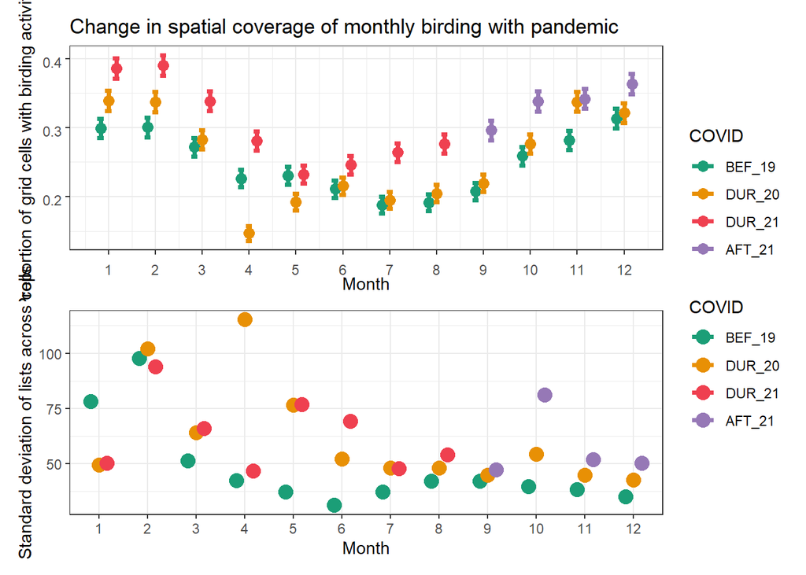

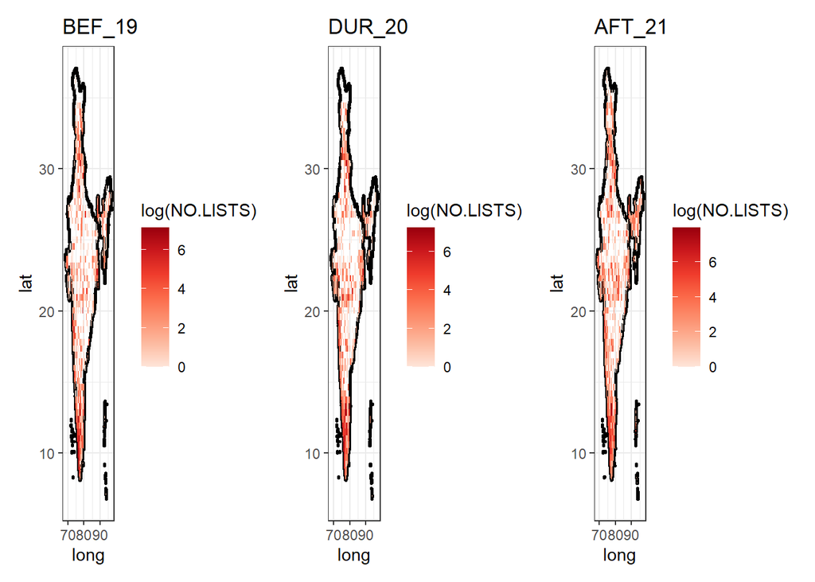

- Both the maps and the graphs show that there were overall more cells covered during the pandemic, and even more after. This can be attributed to general growth in eBirding.
- Proportion of grid cells covered was impacted in both 2020 and 2021 in May, while in 2020 only in April.
- SD of number of lists per cell was higher during the lockdown/second wave months, but otherwise not very different between the three periods.

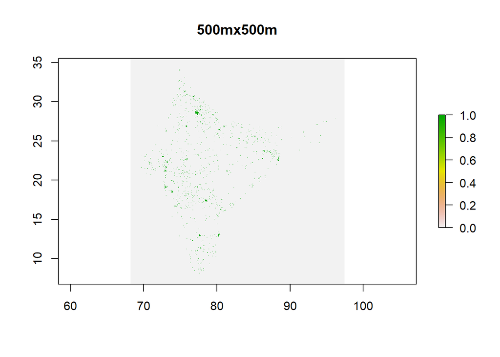

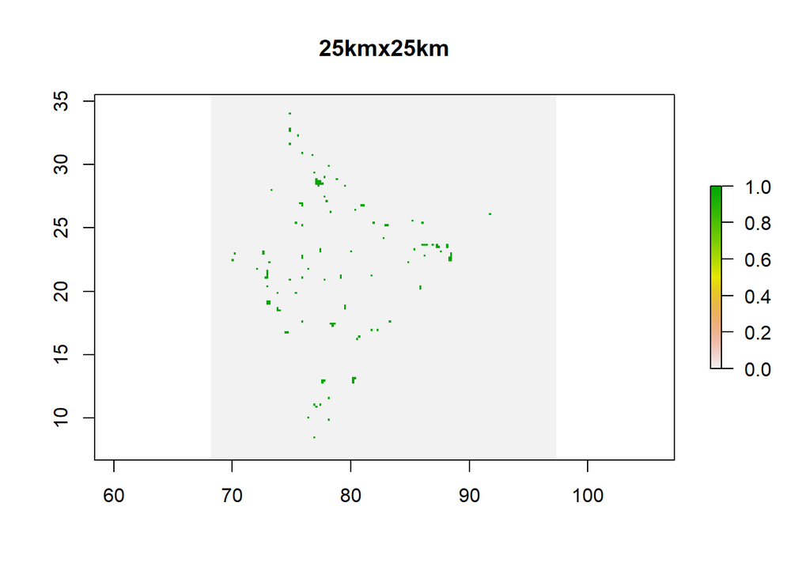

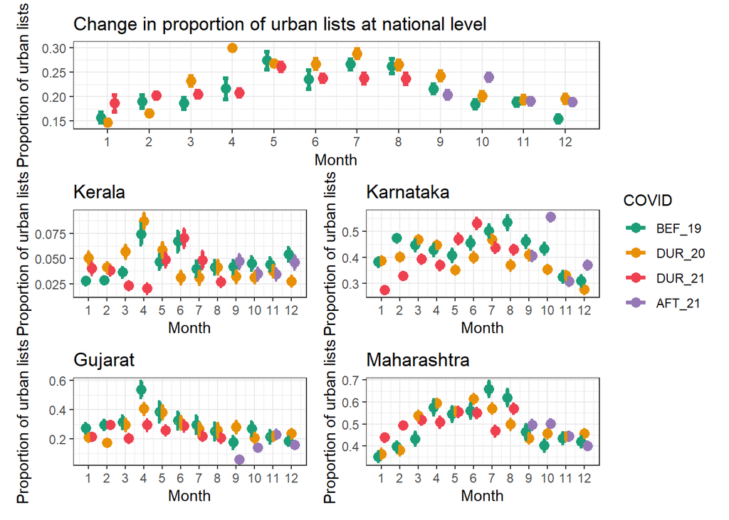

- From this, it looks like only the month of April (or Mar-May) was affected by the pandemic in 2020, while 2021 saw some increased urban birding in October and December.

### Temporal spread

Not “per observer,” as this metric from data POV. Includes duplicate lists, of course.

#### Day-of-week

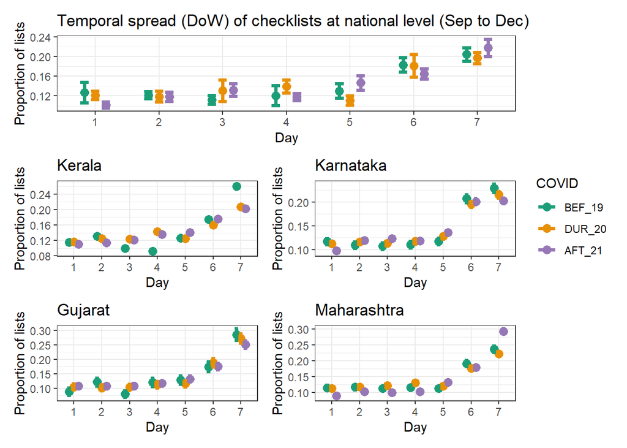

#### Time-of-day

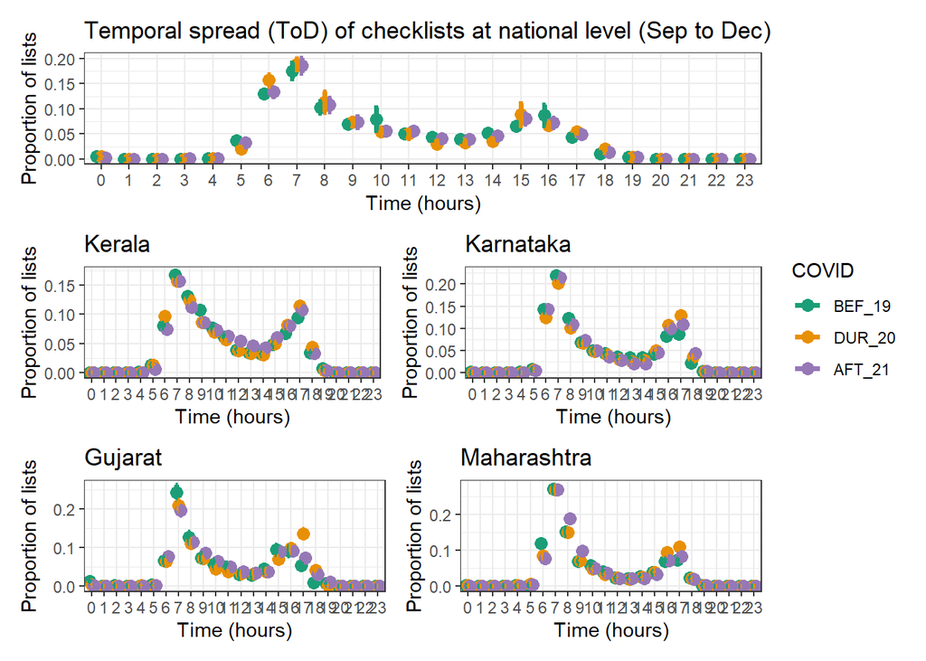

### Media

Not “per observer,” as this metric from data POV. Includes duplicate lists, of course.

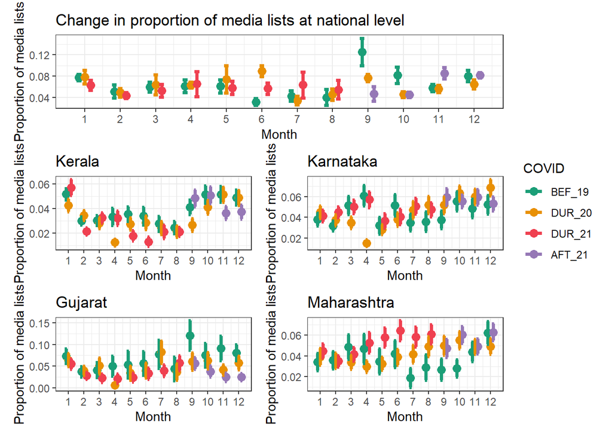

- There is no major difference in proportion of media lists before, during and after the pandemic.

### New birders

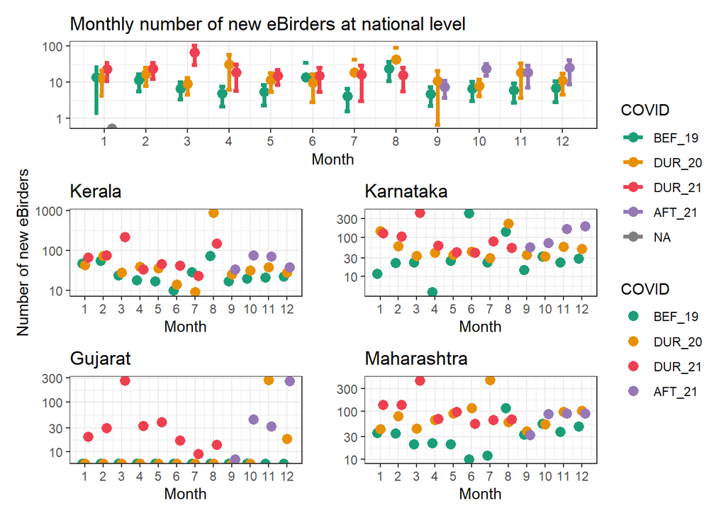

- At the national level, the pandemic has seen a greater number of monthly new eBirders than before, presumably due to greater frequency and impact of outreach initiatives.
- While Kerala and Karnataka both have seen increases in monthly new eBirders with the pandemic, the increase is more striking in Karnataka than in Kerala.